# Sally The Congressperson: Final Production Analysis

B. Papineau

2021–2022

# 1 Introduction

The code and information contained herein constitutes the complete analysis script for the production experiment (forced-choice task) I conducted during my investigation into the relationship between individuals’ gender ideology and the processing and production of gender-neutral language.

The data is fully anonymized, and should be usable by other researchers. If you have any questions or concerns about the code or information contained herein, please feel free to reach out to me via email at branpap[at]stanford[dot]edu.

## 1.1 Preliminaries

I use the following R libraries for the analyses and visualizations contained herein. Additionally, I load the helpers.R script written by Sebastian Schuster, which provides bootstrapped confidence intervals for ggplot outputs.

```r
library(ggplot2)
library(tidyverse)
library(lme4)
library(stringr)
library(languageR)
library(lmerTest)
library(reshape2)
library(grid)

source("helpers.R")
```

I also use two custom color palettes, so I include the code for those here as well[^1]. Finally, all ggplots included herein use the minimal ggplot theme, and we use a custom dodge position for side-by-side bar plots.

```r
bran_palette = c("#7ae7e5", "#fe5f55", "#B2A6DE", "#14342b", "#69385c")
sec_palette = c("#3d405b","#e07a5f","#81b29a","f2cc8f")

theme_set(theme_minimal())

dodge = position_dodge(0.9)
```

### 1.1.1 Frequency Data

We also need the frequency data! These frequency values are taken from the Corpus of Contemporary American English[^2] (COCA), from only the spoken part of the corpus.

```r
frequency <- read.csv("freq_vals.csv")
```

Here we set up objects which will specify both the liberal news sources (lib_cols) and the non-independent news sources (non_inds). These news sources’ left vs. right wing skews were coded according to their positions on the Ad Fontes Media Bias Chart[^3].

```r
lib_cols <- c('ABC','CNN','PBS','NBC','MSNBC','NPR','CBS')
non_inds <- c('ABC','CNN','PBS','NBC','MSNBC','NPR','CBS','FOX')
```

Here we take the raw frequency values obtained from COCA and turn them into words per million values, to account for the varying sizes of the media sources in the corpus. We also code the terms for whether or not the are gender neutral, and whether the neutral forms are compounds (e.g. congressperson) or adoptions of the male form (e.g. actor). Finally, we code them for their form gender.

```r
frequency <- frequency %>%
  mutate(total_left = rowSums(frequency[lib_cols])) %>%
  mutate(total_right = FOX) %>%
  mutate(all_wpm = ((total_left + total_right) / 121500000) * 1000000) %>%
  mutate(left_wpm = (total_left/109300000) * 1000000) %>%
  mutate(right_wpm = (total_right/12200000) * 1000000) %>%
  mutate(neutral_binary = ifelse(gender=="neutral",1,0)) %>%
  mutate(morph_type = ifelse(lexeme!= 'actor' & lexeme!= 'host' & lexeme !='hunter' & lexeme!= 'villain' & lexeme!= 'heir' & lexeme!= 'hero','compound','adoption')) %>%
  rename(form = word) %>%
  mutate(freq_gender = ifelse(form == "actress" | form == "anchorwoman" | form == "stewardess" | form == "businesswoman" | form == 'camerawoman' | form == 'congresswoman' | form == 'craftswoman' | form == 'crewwoman' | form == 'firewoman' | form == 'forewoman'  | form == 'heiress' | form == 'heroine' | form == 'hostess' | form == 'huntress' | form == 'laywoman' | form == 'policewoman' | form == 'saleswoman' | form == 'stuntwoman' | form == 'villainess' | form == 'weatherwoman',"female",ifelse(form == "anchor" | form == "flight attendant" | form == "businessperson" | form == 'camera operator' | form == 'congressperson' | form == 'craftsperson' | form == 'crewmember' | form == 'firefighter' | form == 'foreperson' | form == 'layperson' | form == 'police officer' | form == 'salesperson' | form == 'stunt double' | form == 'meteorologist',"neutral",ifelse(form == "anchorman" | form == "steward" | form == "businessman" | form == 'cameraman' | form == 'congressman' | form == 'craftsman' | form == 'crewman' | form == 'fireman' | form == 'foreman' | form == 'layman' | form == 'policeman' | form == 'salesman' | form == 'stuntman' | form == 'weatherman',"male",'neutral'))))
```

Because we will be working in log space, we need to re-write frequency to avoid zero numbers. However, we still want them to be small to represent their non-presence in the corpus, so we give them a very small WPM value.

```r
frequency[frequency == 0.00000000] <- 0.0001
```

We then take the log WPM of each media type, and subset out the individual media sources (e.g. Fox, CNN), which are no longer informative to the questions we are asking; we want whole-wing WPM values.

```r
frequency <- frequency %>%
  mutate(log_right = log(right_wpm), log_left = log(left_wpm), log_all = log(all_wpm))

frequency <- subset(frequency, select = -c(ABC,CNN,PBS,NBC,MSNBC,NPR,CBS,FOX))
```

Now we can create frequency values for the whole corpus, as well as the left vs. right wing media sources, named so that we can use them in later analyses. We do this by creating three gendered data frames, then joining them into net_lex, below.

```r
# All Media Sources (left and right)
freq_all <- frequency %>%
  select(lexeme,freq_gender,all_wpm) %>%
  pivot_wider(names_from = freq_gender,values_from = all_wpm,names_prefix="all_wpm_")

# Right-wing media only
freq_right <- frequency %>%
  select(lexeme,freq_gender,right_wpm) %>%
  pivot_wider(names_from = freq_gender,values_from = right_wpm,names_prefix="right_wpm_")

# left wing media only
freq_left <- frequency %>%
  select(lexeme,freq_gender,left_wpm) %>%
  pivot_wider(names_from = freq_gender,values_from = left_wpm,names_prefix="left_wpm_")
```

```r
net_lex <- left_join(freq_all,freq_right,by="lexeme")

net_lex <- left_join(net_lex,freq_left,by="lexeme")
```

Now that we have the values for each of these forms, we can calculate the relative expectation of a form appearing as neutral when coreferential with a gendered name. This is because participants were presented with both gendered and gender-neutral options. Note that this DOES assume a 0 probability of choosing the gender-incongruent answer; this is a design choice and has consequences.

```r
net_lex <- net_lex %>%
  mutate(morph_type = ifelse(lexeme!= 'actor' & lexeme!= 'host' & lexeme !='hunter' & lexeme!= 'villain' & lexeme!= 'heir' & lexeme!= 'hero','compound','adoption')) %>%
  mutate(
    fem_odds = log(all_wpm_neutral / all_wpm_female),
    male_odds = case_when(
      morph_type == "adoption" ~ log(all_wpm_neutral / all_wpm_neutral),
      morph_type == "compound" ~ log(all_wpm_neutral / all_wpm_male)
    )
  )
```

Finally, let’s just take out the relevant part of this data frame; the relative odds of a female or male form being selected.

```r
net_lex <- net_lex %>%
  select(lexeme,fem_odds,male_odds)
```

### 1.1.2 Production Task Data Read-in

Having now loaded in the frequency data we will incorporate into the final model, we can load in the data collected from the production task.

```r
prod_data <- read.csv("production_data.csv")
```

**Exclusions**

```r
prod_exclusion <- prod_data %>%
  filter(name=='attention') %>%
  group_by(workerid) %>%
  summarise(accuracy = mean(correct)) %>%
  mutate(exclude = ifelse(accuracy < 0.80,'Yes','No')) %>%
  filter(exclude == "Yes")
```

**Additional Information**

We also need information regarding the participants’ attitudes towards social gender. To accomplish this, we calculate the mean score of their two subscores from the Social Roles Attitudes Questionnaire developed by Baber and Tucker (2006).

```r
gender_transcendence_cols <- c('subject_information.gender_q1','subject_information.gender_q2','subject_information.gender_q3','subject_information.gender_q4','subject_information.gender_q5')

gender_linked_cols <- c('subject_information.gender_q6','subject_information.gender_q7','subject_information.gender_q8','subject_information.gender_q9','subject_information.gender_q10','subject_information.gender_q11','subject_information.gender_q12','subject_information.gender_q13')
```

```r
prod_data <- prod_data %>%
  mutate(gender_trans = 100 - (rowMeans(prod_data[gender_transcendence_cols]))) %>%
  mutate(gender_link = rowMeans(prod_data[gender_linked_cols]))

gender_all = c('gender_trans','gender_link')

prod_data <- prod_data %>%
  mutate(gender_total = rowMeans(prod_data[gender_all]))
```

We also need to code the responses for their gender, whether they were congruent or incongruent, and whether they were neutral or gendered responses. We also include the morphological process underlying the neutral form (same as above in the frequency data), and the political alignments of the participants. We also bin participants according to whether or not they are younger (<40) or older (>40) for visualisation purposes. Finally, we exclude the 2 participants who provided no political alignment or age.

```r
prod_data <- prod_data %>%
  filter(type == "critical") %>%
  mutate(response_gender = ifelse(response == "actress" | response == "anchorwoman" | response == "stewardess" | response == "businesswoman" | response == 'camerawoman' | response == 'congresswoman' | response == 'craftswoman' | response == 'crewwoman' | response == 'firewoman' | response == 'forewoman'  | response == 'heiress' | response == 'heroine' | response == 'hostess' | response == 'huntress' | response == 'laywoman' | response == 'policewoman' | response == 'saleswoman' | response == 'stuntwoman' | response == 'villainess' | response == 'weatherwoman',"female",ifelse(response == "anchor" | response == "flight attendant" | response == "businessperson" | response == 'camera operator' | response == 'congressperson' | response == 'craftsperson' | response == 'crewmember' | response == 'firefighter' | response == 'foreperson' | response == 'layperson' | response == 'police officer' | response == 'salesperson' | response == 'stunt double' | response == 'meteorologist',"neutral",ifelse(response == "anchorman" | response == "steward" | response == "businessman" | response == 'cameraman' | response == 'congressman' | response == 'craftsman' | response == 'crewman' | response == 'fireman' | response == 'foreman' | response == 'layman' | response == 'policeman' | response == 'salesman' | response == 'stuntman' | response == 'weatherman',"male",'neutral')))) %>%
  mutate(congruency = ifelse(gender == response_gender,"true","false")) %>%
  mutate(incongruent = ifelse(gender == "male" & response_gender == "female","incongruent_mtf",ifelse(gender == "female" & response_gender == "male","incongruent_ftm","real"))) %>%
  mutate(neutrality = ifelse(response_gender == "neutral","true","false"))%>%
  mutate(morph_type = ifelse(lexeme!= 'actor' & lexeme!= 'host' & lexeme !='hunter' & lexeme!= 'villain' & lexeme!= 'heir' & lexeme!= 'hero','compound','adoption')) %>%
  mutate(poli_party = ifelse(subject_information.party_alignment == 1 | subject_information.party_alignment == 2,'Republican',ifelse(subject_information.party_alignment == 4 | subject_information.party_alignment == 5,'Democrat','Non-Partisan'))) %>%
  mutate(response_neutral = ifelse(response_gender == "neutral",1,0)) %>%
  mutate(young_old = ifelse(subject_information.age > 40,"old","young")) %>%
  rename(form = response) %>%
  filter(!is.na(subject_information.age)) %>%
  filter(!is.na(poli_party))
```

**Joining independent data**

Now that we have this information, we want to left join our frequency information so that we can use it in later analyses.

```r
final_prod <- left_join(prod_data,net_lex,by="lexeme")
```

We can at this point subset out a bunch of extraneous information, keeping only what we need for further analysis.

```r
final_prod <- subset(final_prod, select = -c(error,subject_information.asses,subject_information.enjoyment,subject_information.gender_q1,subject_information.gender_q2,subject_information.gender_q3,subject_information.gender_q4,subject_information.gender_q5,subject_information.gender_q6,subject_information.gender_q7,subject_information.gender_q8,subject_information.gender_q9,subject_information.gender_q10,subject_information.gender_q11,subject_information.gender_q12,subject_information.gender_q13))
```

**Final Data Preparation**

Finally, we want to code each trial with its relative log odds, given the gender of the referent in that trial. That is, when participants saw a female name, we need to use the pre-calculated neutrality expectation for female forms. When participants saw a male name, we need to use the male form values. After this, we center the gender ideology score for inclusion in analyses.

```r
final_prod <- final_prod %>%
  mutate(log_odds = case_when(
    gender == "male" ~ male_odds,
    gender == "female" ~ fem_odds
  )) %>%
  mutate(c_gender_total = scale(gender_total,scale=FALSE)) %>%
  mutate(poli_party = factor(poli_party,ordered = FALSE)) %>%
  mutate(trial_gender = factor(gender,ordered = FALSE)) %>%
  mutate(c_trial_gender = scale(as.numeric(trial_gender),scale=FALSE)) %>%
  mutate(c_age = scale(subject_information.age, scale=FALSE)) %>%
  mutate(c_log_odds = scale(log_odds, scale=TRUE))
```

*Before we subset out the incongruents*

Before we remove the incongruent productions, we need to save them in a separate data frame for later analysis & visualization.

```r
prod_all <- final_prod
```

Okay, now we can filter out the incongruent responses.

```r
final_prod_all <- final_prod %>%
  filter(incongruent == "real")
```

```r
final_prod <- final_prod %>%
  filter(incongruent == "real")
```

# 2 Analysis

Now that we have everything we actually need, we can start in on analysis.

## 2.1 Primary Models

Now, in order to see what comes out as statistically significant for each of the political parties, we want to run some mixed effects logistic models (logistic because our output variable is binary). We run separate logistic models for each party for reasons of interpetability.

### 2.1.1 Democrats

We start with the democrats, so we set the reference level for trial gender as male (for all the political parties) and continue on by creating a data frame for the democrats and running their model.

```r
final_prod$trial_gender = relevel(final_prod$trial_gender, ref="male")

dems <- final_prod %>%
  filter(poli_party == "Democrat")
```

```r
dem_model <- glmer(as.factor(response_neutral)~c_trial_gender*c_gender_total + c_log_odds + (1|workerid) + (1|lexeme),data=dems,family="binomial",control = glmerControl(optCtrl = list(maxfun=2e4)))
```

```r
summary(dem_model)
```

```
Generalized linear mixed model fit by maximum likelihood (Laplace Approximation) [glmerMod]
 Family: binomial  ( logit )
Formula: as.factor(response_neutral) ~ c_trial_gender * c_gender_total +
    c_log_odds + (1 | workerid) + (1 | lexeme)
   Data: dems
Control: glmerControl(optCtrl = list(maxfun = 20000))

     AIC      BIC   logLik deviance df.resid
  3110.8   3152.3  -1548.4   3096.8     2782

Scaled residuals:
    Min      1Q  Median      3Q     Max
-6.1248 -0.6977  0.3148  0.6317  4.6020

Random effects:
 Groups   Name        Variance Std.Dev.
 workerid (Intercept) 0.7973   0.8929
 lexeme   (Intercept) 0.3771   0.6141
Number of obs: 2789, groups:  workerid, 151; lexeme, 20

Fixed effects:
                                Estimate Std. Error z value Pr(>|z|)
(Intercept)                    4.188e-01  1.634e-01   2.564 0.010360 *
c_trial_gender                 2.029e+00  1.656e-01  12.251  < 2e-16 ***
c_gender_total                -1.691e-02  4.775e-03  -3.542 0.000397 ***
c_log_odds                     1.368e+00  1.205e-01  11.351  < 2e-16 ***
c_trial_gender:c_gender_total  3.571e-05  5.211e-03   0.007 0.994531
---
Signif. codes:  0 ‘***’ 0.001 ‘**’ 0.01 ‘*’ 0.05 ‘.’ 0.1 ‘ ’ 1

Correlation of Fixed Effects:
            (Intr) c_trl_ c_gnd_ c_lg_d
c_tril_gndr  0.027
c_gendr_ttl  0.107 -0.027
c_log_odds   0.037  0.814 -0.024
c_trl_gn:__ -0.004  0.149  0.002  0.023
optimizer (Nelder_Mead) convergence code: 0 (OK)
Model failed to converge with max|grad| = 0.0054894 (tol = 0.002, component 1)
```

### 2.1.2 Republicans

Now we do the same for the republicans.

```r
reps <- final_prod %>%
  filter(poli_party == "Republican")
```

```r
rep_model <- glmer(as.factor(response_neutral)~c_trial_gender*c_gender_total + c_log_odds + (1|workerid) + (1|lexeme),data=reps,family = "binomial")
```

```r
summary(rep_model)
```

```
Generalized linear mixed model fit by maximum likelihood (Laplace Approximation) [glmerMod]
 Family: binomial  ( logit )
Formula: as.factor(response_neutral) ~ c_trial_gender * c_gender_total +
    c_log_odds + (1 | workerid) + (1 | lexeme)
   Data: reps

     AIC      BIC   logLik deviance df.resid
  2184.7   2224.1  -1085.3   2170.7     2055

Scaled residuals:
    Min      1Q  Median      3Q     Max
-3.1669 -0.5925 -0.2256  0.6042  7.0334

Random effects:
 Groups   Name        Variance Std.Dev.
 workerid (Intercept) 0.3606   0.6005
 lexeme   (Intercept) 0.7701   0.8775
Number of obs: 2062, groups:  workerid, 108; lexeme, 20

Fixed effects:
                                Estimate Std. Error z value Pr(>|z|)
(Intercept)                   -0.3867609  0.2152642  -1.797   0.0724 .
c_trial_gender                 2.3992008  0.2021921  11.866   <2e-16 ***
c_gender_total                 0.0004068  0.0051905   0.078   0.9375
c_log_odds                     1.5224217  0.1430234  10.645   <2e-16 ***
c_trial_gender:c_gender_total -0.0076519  0.0071844  -1.065   0.2868
---
Signif. codes:  0 ‘***’ 0.001 ‘**’ 0.01 ‘*’ 0.05 ‘.’ 0.1 ‘ ’ 1

Correlation of Fixed Effects:
            (Intr) c_trl_ c_gnd_ c_lg_d
c_tril_gndr -0.022
c_gendr_ttl -0.151  0.018
c_log_odds   0.000  0.800  0.005
c_trl_gn:__  0.008 -0.233 -0.047 -0.011
```

### 2.1.3 Non-Partisans

Finally, the non-partisans.

```r
inds <- final_prod %>%
  filter(poli_party == "Non-Partisan")
```

```r
ind_model <- glmer(response_neutral~c_trial_gender*c_gender_total + c_log_odds + (1|workerid) + (1|lexeme),data=inds, family="binomial")
```

```r
summary(ind_model)
```

```
Generalized linear mixed model fit by maximum likelihood (Laplace Approximation) [glmerMod]
 Family: binomial  ( logit )
Formula: response_neutral ~ c_trial_gender * c_gender_total + c_log_odds +
    (1 | workerid) + (1 | lexeme)
   Data: inds

     AIC      BIC   logLik deviance df.resid
   766.7    798.6   -376.4    752.7      696

Scaled residuals:
    Min      1Q  Median      3Q     Max
-4.4968 -0.6090  0.1949  0.5910  3.1224

Random effects:
 Groups   Name        Variance Std.Dev.
 workerid (Intercept) 0.8669   0.9311
 lexeme   (Intercept) 0.7952   0.8917
Number of obs: 703, groups:  workerid, 37; lexeme, 20

Fixed effects:
                               Estimate Std. Error z value Pr(>|z|)
(Intercept)                    0.214191   0.272536   0.786    0.432
c_trial_gender                 2.245023   0.325214   6.903 5.08e-12 ***
c_gender_total                 0.001629   0.013432   0.121    0.903
c_log_odds                     1.498234   0.226447   6.616 3.68e-11 ***
c_trial_gender:c_gender_total -0.012731   0.014448  -0.881    0.378
---
Signif. codes:  0 ‘***’ 0.001 ‘**’ 0.01 ‘*’ 0.05 ‘.’ 0.1 ‘ ’ 1

Correlation of Fixed Effects:
            (Intr) c_trl_ c_gnd_ c_lg_d
c_tril_gndr  0.022
c_gendr_ttl  0.140  0.017
c_log_odds   0.043  0.782  0.027
c_trl_gn:__ -0.007  0.106 -0.014 -0.041
```

### 2.1.4 Political Analysis

In order to confirm that there was a significant difference between political parties in their proportions of neutral responses, we run a simple model predicting gender neutral responses from just political party:

```r
final_prod_no <- final_prod %>%
  filter(lexeme != "firefighter") %>%
  filter(lexeme != "meteorologist")
```

```r
all_poli <- glmer(response_neutral~poli_party + (1|lexeme) + (1|workerid), data=final_prod_no, family="binomial")
```

```r
summary(all_poli)
```

```
Generalized linear mixed model fit by maximum likelihood (Laplace Approximation) [glmerMod]
 Family: binomial  ( logit )
Formula: response_neutral ~ poli_party + (1 | lexeme) + (1 | workerid)
   Data: final_prod_no

     AIC      BIC   logLik deviance df.resid
  5805.0   5837.5  -2897.5   5795.0     4979

Scaled residuals:
    Min      1Q  Median      3Q     Max
-4.1767 -0.6949  0.2153  0.7187  4.1576

Random effects:
 Groups   Name        Variance Std.Dev.
 workerid (Intercept) 0.580    0.7615
 lexeme   (Intercept) 1.104    1.0509
Number of obs: 4984, groups:  workerid, 296; lexeme, 18

Fixed effects:
                       Estimate Std. Error z value Pr(>|z|)
(Intercept)              0.3312     0.2597   1.275    0.202
poli_partyNon-Partisan  -0.3489     0.1741  -2.004    0.045 *
poli_partyRepublican    -0.8312     0.1202  -6.914 4.72e-12 ***
---
Signif. codes:  0 ‘***’ 0.001 ‘**’ 0.01 ‘*’ 0.05 ‘.’ 0.1 ‘ ’ 1

Correlation of Fixed Effects:
            (Intr) pl_N-P
pl_prtyNn-P -0.134
pl_prtyRpbl -0.195  0.292
```

## 2.2 Visualization

```r
base <- prod_all %>%
  mutate(response_gender = case_when(
    response_gender == "male/neutral" ~ "neutral",
    TRUE ~ response_gender
  )) %>%
  select(workerid,gender,response_gender) %>%
  rename(trial_gender = gender) %>%
  mutate(trial_gender = as.factor(trial_gender),
         response_gender = as.factor(response_gender))
```

```r
prod_to_expand <- prod_all %>%
  mutate(response_gender = case_when(
    response_gender == "male/neutral" ~ "neutral",
    TRUE ~ response_gender
  )) %>%
  select(workerid,gender,response_gender,gender_total,poli_party,incongruent,trial_no) %>%
  mutate(ideology = cut_number(gender_total,n=3,labels=c("progressive","moderate","conservative"))) %>%
  rename(trial_gender = gender) %>%
  mutate(trial_gender = as.factor(trial_gender),
         response_gender = as.factor(response_gender))
```

```r
expanded_prod <- prod_to_expand %>%
  mutate(id = as.factor(row_number())) %>%
  expand_grid(c("male","female","neutral"),base$id) %>%
  rename(response_old = response_gender)
```

```r
colnames(expanded_prod)[10] <- "response_gender"
```

```r
expanded_prod <- expanded_prod %>%
  group_by(id) %>%
  mutate(response = case_when(response_gender == response_old ~ 1,TRUE ~ 0)) %>%
  select(-response_old)
```

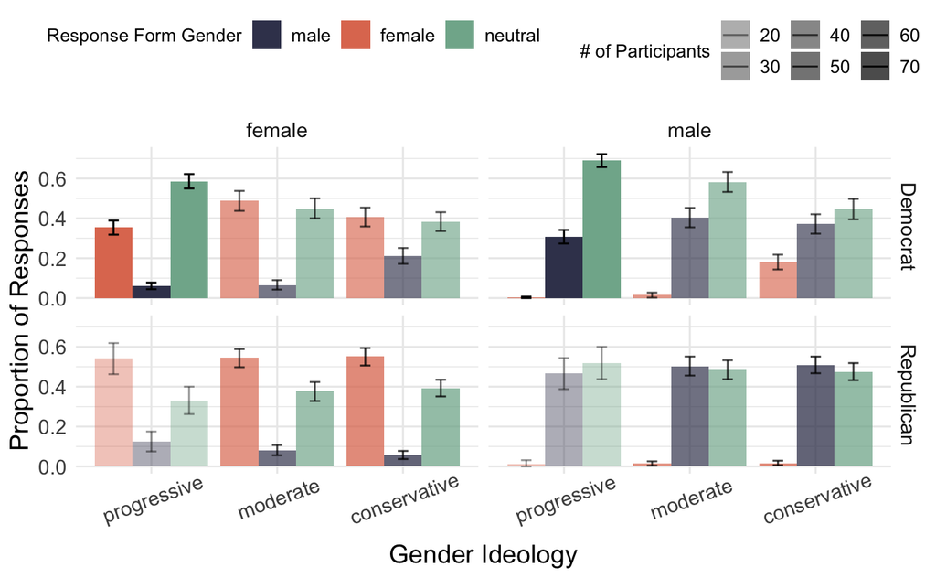

```r
expanded_prod %>%
  filter(poli_party != "Non-Partisan") %>%
  group_by(response_gender,trial_gender,ideology,poli_party) %>%
  summarize(proportion = mean(response),
            CI.Low = ci.low(response),
            CI.High = ci.high(response),
            obs = n(),
            participants = n_distinct(workerid)) %>%
  ungroup() %>%
  mutate(YMin = proportion - CI.Low,
         YMax = proportion + CI.High) %>%
  ggplot(aes(x=ideology,
             y=proportion,
             fill=response_gender,
             alpha=as.numeric(participants))) +
  geom_bar(stat="identity",
           position = dodge) +
  geom_errorbar(aes(ymin = YMin, ymax=YMax),
                position = dodge,
                width=0.25) +
  facet_grid(poli_party~trial_gender) +
  scale_fill_manual(values = sec_palette, limits=c("male","female","neutral")) +
  scale_alpha(range=c(0.4,1)) +
  labs(y="Proportion of Responses",x="Gender Ideology", fill="Response Form Gender",alpha = "# of Participants") +
  theme(text=element_text(size=14)) +
  theme(axis.text.x = element_text(angle=20, vjust=.8)) +
  theme(legend.position = "top", legend.text = element_text(size=10), legend.title = element_text(size=10))
```

### 2.2.1 Build-Up Visuals

```r
prod_viz <- prod_to_expand
```

[output not shown]

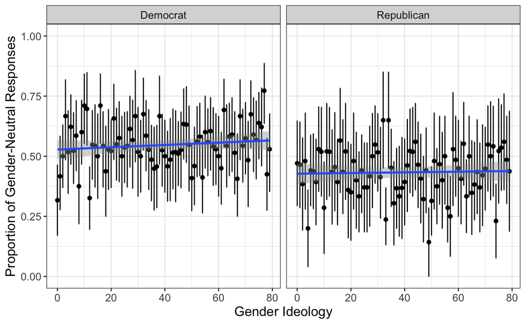

```r
prod_viz %>%
  mutate(incongruent == "real") %>%
  mutate(response = case_when(
    response_gender == "neutral" ~ 1,
    TRUE ~ 0
  )) %>%
  filter(poli_party != "Non-Partisan") %>%
  group_by(trial_no,poli_party) %>%
  summarize(proportion = mean(response),
            CI.Low = ci.low(response),
            CI.High = ci.high(response)) %>%
  ungroup() %>%
  mutate(YMin = proportion - CI.Low,
         YMax = proportion + CI.High) %>%
  ggplot(aes(x=trial_no,
             y=proportion)) +
  geom_point() +
  geom_errorbar(aes(ymin = YMin, ymax=YMax),
                position = dodge,
                width=0.25) +
 # scale_fill_manual(values = bran_palette, limits=c("Democrat","Republican")) +
  #scale_alpha_discrete(range = c(0.4, 1)) +
  labs(x="Gender Ideology", y="Proportion of Gender-Neutral Responses") +
  theme_bw() +
  theme(legend.position = "none", text = element_text(size=13)) +
  ylim(0,1) +
  geom_smooth(method="lm") +
  facet_wrap(~poli_party)
```

```r
prod_viz %>%
  mutate(incongruent == "real") %>%
  mutate(response = case_when(
    response_gender == "neutral" ~ 1,
    TRUE ~ 0
  )) %>%
  filter(poli_party != "Non-Partisan") %>%
  group_by(poli_party,ideology) %>%
  summarize(proportion = mean(response),
            CI.Low = ci.low(response),
            CI.High = ci.high(response)) %>%
  ungroup() %>%
  mutate(YMin = proportion - CI.Low,
         YMax = proportion + CI.High) %>%
  ggplot(aes(x=ideology,
             y=proportion,
             fill=poli_party,
             alpha=ideology)) +
  geom_bar(stat="identity",
           position = dodge) +
  geom_errorbar(aes(ymin = YMin, ymax=YMax),
                position = dodge,
                width=0.25) +
  scale_fill_manual(values = bran_palette, limits=c("Democrat","Republican")) +
  scale_alpha_discrete(range = c(0.4, 1)) +
  labs(x="Gender Ideology", y="Proportion of Gender-Neutral Responses") +
  theme_bw() +
  theme(legend.position = "none", text = element_text(size=13)) +
  ylim(0,1) +
  facet_wrap(~poli_party)
```

[output not shown]

[figure not shown]

## 2.3 Auxiliary Analyses

We also asked some additional questions of the data, which are included here.

### 2.3.1 Neutral Responses by Character Gender

Looking at the effect of character gender in the vignettes, we see above that female names elicit fewer neutral responses than do the male names. We can calculate the proportions here:

```r
final_prod %>%
  group_by(trial_gender) %>%
  summarise(mean_neutral = mean(response_neutral))
```

| trial_gender | mean_neutral |
| --- | --- |
| male | 0.5735809 |
| female | 0.4900000 |

### 2.3.2 Neutral Responses by Political Party

We can do the same by political party, irrespective of gender ideology, to confirm that Democrats are more likely to use neutral responses than Republicans.

```r
final_prod %>%
  group_by(poli_party) %>%
  summarise(mean_neutral = mean(response_neutral))
```

| poli_party | mean_neutral |
| --- | --- |
| Democrat | 0.5926856 |
| Non-Partisan | 0.5348506 |
| Republican | 0.4515034 |

### 2.3.3 Correlation Between Right & Left-wing News Sources

Finally, in order to confirm that the language differences between left-wing and right-wing media are not significant enough to warrant using both separately as predictors in the model (which we did not do), we can test the correlation between the log frequencies of the two wings’ medias.

```r
cor(frequency$log_right,frequency$log_left)
```

```
[1] 0.8260275
```

# 3 Comments

Stepping out of the analyses, if we are interested in the qualitative comments provided by participants, we can see those (making sure we only see each comment once per participant; not per response!).

```r
prod_comments <- final_prod %>%
  group_by(workerid) %>%
  mutate(comments = paste(unique(subject_information.comments)))

unique(final_prod$subject_information.comments)
```

```
 [1] "Thank you."
 [2] "No"
 [3] "I am very enjoy for this experiment. "
 [4] ""
 [5] "i think the study is underpaying"
 [6] "NO COMMENT"
 [7] "good study. "
 [8] "no"
 [9] "Nothing else"
[10] "Nice"
[11] "it was best experiment"
[12] "interesting survey"
[13] "I like this experiment. "
[14] "I find it both strange and perplexing that gender roles and sex still play a huge role in how people treat others and how they perceive them. Growing up, I was taught not to call a mailperson a mailman or mailwoman because jobs should be equal amongst all sexes and genders. My grandmother, who…
[15] "it was best experiment i do"
```

[output cut: 47 more lines]

[^1]: It is my hope and intention that these color palettes be color-blind friendly. If you have accessibility concerns, please do not hesitate to reach out to me!
[^2]: https://www.english-corpora.org/coca/
[^3]: https://adfontesmedia.com